# EDA

Sarah Gaeta

4/25/2021

```r
airbnb =  read_csv("clean_airbnb.csv", col_types = cols(last_review = col_date(format = "%Y-%m-%d")))
```

# What causes prices to be higher and can we make a model to predict the price?

# Do the number of reviews differ per borough?

# Does price vary with neighborhood?

# cluster neighborhood

First, let’s clean the data

```r
airbnb = airbnb %>% na.omit()
#next remove all 0's from price
price_0 = which(airbnb$price >0, )
airbnb = airbnb[price_0, ]
#use minimum nights <= 20
```

First, we will plot the correlograms between the columns of numerical type

```r
updated_airbnb = airbnb %>% keep(is.numeric)
updated = updated_airbnb[,-c(1,2,3,4)] %>% na.omit()
#pairs(updated)
```

Next, we will plot the respective correlation matrix between the numerical variables:

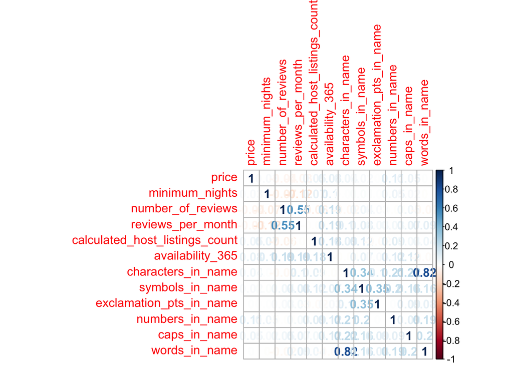

```r
corrplot(cor(updated), method = "number")
```

```r
summary(updated)
```

```
##      price         minimum_nights     number_of_reviews reviews_per_month
##  Min.   :   10.0   Min.   :   1.000   Min.   :  1.00    Min.   : 0.010
##  1st Qu.:   69.0   1st Qu.:   1.000   1st Qu.:  3.00    1st Qu.: 0.190
##  Median :  102.0   Median :   2.000   Median :  9.00    Median : 0.710
##  Mean   :  142.5   Mean   :   5.879   Mean   : 29.31    Mean   : 1.372
##  3rd Qu.:  170.0   3rd Qu.:   4.000   3rd Qu.: 33.00    3rd Qu.: 2.020
##  Max.   :10000.0   Max.   :1250.000   Max.   :629.00    Max.   :58.500
##  calculated_host_listings_count availability_365 characters_in_name
##  Min.   :  1.000                Min.   :  0.0    Min.   :  1.00
##  1st Qu.:  1.000                1st Qu.:  0.0    1st Qu.: 31.00
##  Median :  1.000                Median : 55.0    Median : 37.00
##  Mean   :  5.176                Mean   :114.8    Mean   : 37.03
##  3rd Qu.:  2.000                3rd Qu.:229.0    3rd Qu.: 46.00
##  Max.   :327.000                Max.   :365.0    Max.   :161.00
##  symbols_in_name exclamation_pts_in_name numbers_in_name    caps_in_name
##  Min.   : 0      Min.   :0.0000          Min.   : 0.0000   Min.   : 0.00
##  1st Qu.: 0      1st Qu.:0.0000          1st Qu.: 0.0000   1st Qu.: 3.00
##  Median : 1      Median :0.0000          Median : 0.0000   Median : 4.00
##  Mean   : 1      Mean   :0.1655          Mean   : 0.4983   Mean   : 5.59
##  3rd Qu.: 2      3rd Qu.:0.0000          3rd Qu.: 1.0000   3rd Qu.: 6.00
##  Max.   :35      Max.   :9.0000          Max.   :13.0000   Max.   :45.00
##  words_in_name
##  Min.   : 1.000
##  1st Qu.: 5.000
##  Median : 6.000
##  Mean   : 5.782
##  3rd Qu.: 7.000
##  Max.   :27.000
```

We will get rid of zero price, because a price of 0 is senseless:

```r
price_over0 = which(airbnb$price > 0)
airbnb = airbnb[price_over0, ]
```

Then, get the count of each borough:

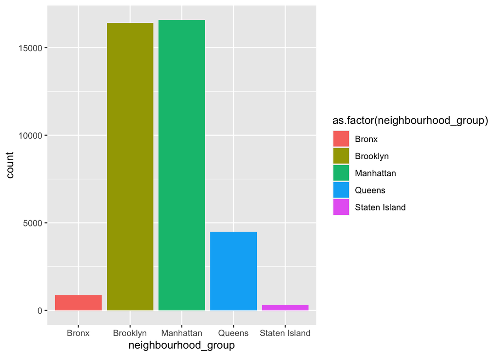

```r
ggplot(airbnb, aes(x=neighbourhood_group, fill = as.factor(neighbourhood_group))) + geom_bar()
```

Look at the mean price for each borough:

First, we want to see if prices are greater for certain neighborhood groups: #cheaper airbnbs

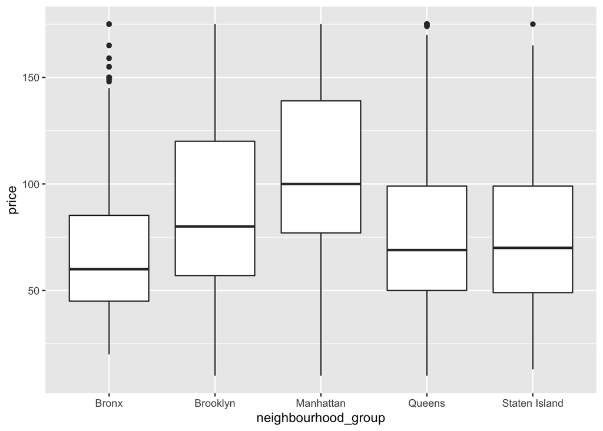

```r
ggplot(airbnb[which(airbnb$price <= 175), ], aes(x= neighbourhood_group , y= price)) + geom_boxplot()
```

average listenings in Manhattan more expensive ish than average of other groups.

#more expensive:

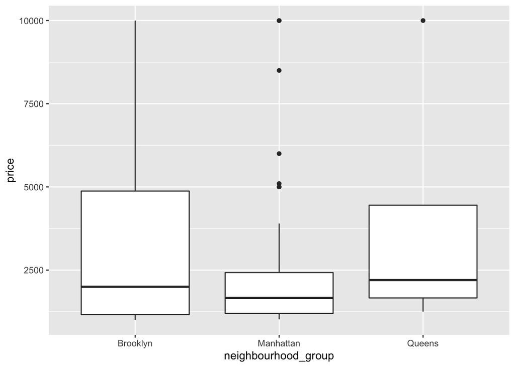

```r
ggplot(airbnb[which(airbnb$price > 1000), ], aes(x= neighbourhood_group , y= price)) + geom_boxplot()
```

more variability around the more expensive groups in Broklyn and Queens